# lab10_kmeans_clustering

```python
from os.path import join
import pandas as pd
import numpy as np
import matplotlib.pyplot as plt
import seaborn as sns
import matplotlib.cm as cm
from sklearn.metrics import silhouette_score, silhouette_samples
from sklearn.cluster import KMeans
from sklearn.cluster import AgglomerativeClustering

sns.set()
```

## **Import preprocessed data**

```python
df = pd.read_csv(join('..', 'data', 'data_preprocessed.csv'))
```

```python
df.head()
```

|  | age | income | frq | rcn | mnt | clothes | kitchen | small_appliances | toys | house_keeping | ... | oh_status_Widow | oh_gender_M | oh_dependents_1.0 | oh_description_Kind of OK | oh_description_Meh... | oh_description_OK nice! | oh_description_Take my money!! | PC0 | PC1 | PC2 |
| --- | --- | --- | --- | --- | --- | --- | --- | --- | --- | --- | --- | --- | --- | --- | --- | --- | --- | --- | --- | --- | --- |
| 0 | 78 | 0.743162 | 1.191605 | 0.457819 | 1402 | -0.617023 | -0.243065 | 1.216847 | 0.495837 | -0.499274 | ... | 0.0 | 1.0 | 0.0 | 0.0 | 0.0 | 0.0 | 1.0 | 0.896356 | -1.937697 | 1.120781 |
| 1 | 88 | 1.559488 | 1.100011 | -1.535723 | 1537 | 0.166160 | -0.790228 | 0.740464 | -0.374374 | -0.631907 | ... | 0.0 | 0.0 | 0.0 | 0.0 | 0.0 | 0.0 | 1.0 | 1.981092 | -1.421498 | 0.785625 |
| 2 | 34 | -1.548542 | -0.823463 | 0.557496 | 44 | -0.834573 | 1.672006 | -0.371096 | -0.809480 | 2.286023 | ... | 0.0 | 1.0 | 1.0 | 1.0 | 0.0 | 0.0 | 0.0 | -2.813108 | 0.381440 | -0.780867 |
| 3 | 69 | 0.845528 | 0.550447 | -1.402820 | 888 | 0.383710 | 0.440889 | -0.768082 | -0.084304 | -0.234007 | ... | 0.0 | 0.0 | 1.0 | 0.0 | 0.0 | 1.0 | 0.0 | 1.247013 | -0.514177 | -1.302203 |
| 4 | 69 | 0.782435 | 1.008417 | -0.871209 | 1138 | 0.340200 | -0.243065 | -0.053508 | -0.374374 | -0.366640 | ... | 0.0 | 0.0 | 1.0 | 0.0 | 0.0 | 0.0 | 1.0 | 1.781920 | -0.704805 | -0.443376 |

5 rows × 35 columns

```python
df.columns
```

```
Index(['age', 'income', 'frq', 'rcn', 'mnt', 'clothes', 'kitchen',
       'small_appliances', 'toys', 'house_keeping', 'dependents',
       'per_net_purchase', 'gender', 'education', 'status', 'description',
       'birth_year', 'spent_online', 'oh_education_2nd Cycle',
       'oh_education_Graduation', 'oh_education_Master', 'oh_education_PhD',
       'oh_status_Married', 'oh_status_Single', 'oh_status_Together',
       'oh_status_Widow', 'oh_gender_M', 'oh_dependents_1.0',
       'oh_description_Kind of OK', 'oh_description_Meh...',
       'oh_description_OK nice!', 'oh_description_Take my money!!', 'PC0',
       'PC1', 'PC2'],
      dtype='object')
```

```python
# Splitting feature names into groups
# Remember which metric_features we decided to keep?
metric_features = ['income',
 'frq',
 'rcn',
 'clothes',
 'kitchen',
 'small_appliances',
 'toys',
 'house_keeping',
 'per_net_purchase',
 'spent_online']

non_metric_features = df.columns[df.columns.str.startswith('oh_')].tolist() # CODE HERE
pc_features = df.columns[df.columns.str.startswith('PC')].tolist()  # CODE HERE

unused_features = [i for i in df.columns if i not in (metric_features+non_metric_features+pc_features) ]
```

```python
print('metric_features:', metric_features)
print('\nnon_metric_features:', non_metric_features)
print('\nunused_features:', unused_features)
print('\npc_features:', pc_features)
```

[output not shown]

# **K-Means Clustering**

What is K-Means clustering? How does it work?

### How is it computed?

[figure not shown]

### **Characteristics:**

- *Number of clusters* need to be set apriori
- One of the *fastest* clustering algorithms
- The results *depend on the initialization* (stochastic)
- Prone to *local optima*
- Favors *convex* (round shape) and *isotropic* (same shape) clusters

[figure not shown]

**Some videos showing how K-Means works:**

(You might want to mute the videos before playing)

How K-Means works: https://www.youtube.com/watch?v=5I3Ei69I40s

Effects of different initializations: https://www.youtube.com/watch?v=9nKfViAfajY

### How to apply K-Means clustering?

```python
kmclust = KMeans(n_clusters=8, init='random', n_init=10, random_state=1)
```

#### **Parameters `KMeans`:**

- **`n_clusters`**: The number of clusters to form as well as the number of centroids to generate.
- **`init`**: Method for initialization:
  - `k-means++`: selects initial cluster centers for k-mean clustering in a smart way to speed up convergence.
  - `random`: choose k observations (rows) at random from data for the initial centroids.
- **`n_init`**: Number of time the k-means algorithm will be run with different centroid seeds. The final results will be the best output of n_init consecutive runs in terms of inertia.
  - Default is 10. $\rightarrow$ **run the same cluster 10 times and chose the best solution**
- **`max_iter`**: Maximum number of iterations of the k-means algorithm for a single run.
- **`tol`**: Relative tolerance with regards to Frobenius norm of the difference in the cluster centers of two consecutive iterations to declare convergence.
- **`random_state`**: Determines random number generation for centroid initialization. Use an int to make the randomness deterministic.

```python
# The fit method
kmclust.fit(df[metric_features])
```

```
KMeans(init='random', n_init=10, random_state=1)
```

#### **🔴 Important:**

Só usamos as **metric features** para o clustering, pois as categóricas não fazem sentido para o algoritmo KMeans (pq que é baseado em distâncias e as distâncias entre categorias não fazem sentido).

```python
df.info()
```

```
<class 'pandas.core.frame.DataFrame'>
RangeIndex: 8817 entries, 0 to 8816
Data columns (total 35 columns):
 #   Column                          Non-Null Count  Dtype
---  ------                          --------------  -----
 0   age                             8817 non-null   int64
 1   income                          8817 non-null   float64
 2   frq                             8817 non-null   float64
 3   rcn                             8817 non-null   float64
 4   mnt                             8817 non-null   int64
 5   clothes                         8817 non-null   float64
 6   kitchen                         8817 non-null   float64
 7   small_appliances                8817 non-null   float64
 8   toys                            8817 non-null   float64
 9   house_keeping                   8817 non-null   float64
```

[output cut: 27 more lines]

#### **🟢 Confirm**

- Confirmar que `metric_features` não têm **Ordinal Encoding** e **One-Hot Encoding**
  - **NOTA | Projeto** dist. entre regiões no projeto não fazem sentido

```python
# The predict method
kmclust.predict(df[metric_features])
```

```
array([6, 6, 4, ..., 3, 0, 5])
```

```python
# The transform method
pd.DataFrame(kmclust.transform(df[metric_features]))
```

|  | 0 | 1 | 2 | 3 | 4 | 5 | 6 | 7 |
| --- | --- | --- | --- | --- | --- | --- | --- | --- |
| 0 | 2.179833 | 4.135406 | 3.762119 | 3.709777 | 5.337195 | 3.228544 | 1.184716 | 3.833997 |
| 1 | 3.264825 | 3.730586 | 5.165610 | 4.074380 | 6.490986 | 3.646307 | 1.897354 | 4.444833 |
| 2 | 4.349902 | 4.831557 | 3.142586 | 3.615440 | 2.709018 | 5.708241 | 5.592302 | 4.178844 |
| 3 | 2.470914 | 2.407108 | 4.415282 | 3.212936 | 5.087074 | 2.209629 | 2.679578 | 3.456535 |
| 4 | 2.639834 | 2.645893 | 4.338893 | 3.356798 | 5.585652 | 1.477904 | 1.961531 | 3.384525 |
| ... | ... | ... | ... | ... | ... | ... | ... | ... |
| 8812 | 2.999686 | 2.661955 | 4.341368 | 3.050741 | 5.273895 | 2.362368 | 3.029492 | 3.706530 |
| 8813 | 3.849048 | 2.782847 | 5.092738 | 3.835394 | 6.060680 | 1.949553 | 3.605498 | 3.999756 |
| 8814 | 3.917148 | 2.422340 | 3.007328 | 1.400354 | 4.047036 | 4.235755 | 4.491649 | 2.992527 |
| 8815 | 2.489050 | 3.670751 | 3.036769 | 3.144707 | 4.415884 | 3.051683 | 2.551593 | 3.182286 |
| 8816 | 4.520489 | 5.012224 | 6.125355 | 5.863140 | 7.324810 | 2.417308 | 3.872173 | 5.152200 |

8817 rows × 8 columns

##### **What do these values represent?**

> Distância de cada ponto de dado aos centros dos clusters identificados pelo algoritmo **K-Means**.
- Cada **linha** do `df` corresponde a um ponto de dado
- Cada **coluna** do `df` corresponde a um cluster específico
  - Indica quão distante cada ponto está de cada centro de cluster

### **How can we improve the initialization step?**

```python
# Different initialization method and provide more n_init
kmclust = KMeans(n_clusters=8, init='k-means++', n_init=15, random_state=1)
kmclust.fit(df[metric_features])
```

```
KMeans(n_init=15, random_state=1)
```

> **K-Means++** é um método de inicialização que seleciona os centros dos clusters de forma inteligente para acelerar a convergência do algoritmo.
- **Vantagem**:
  - Inicialização dos centroides sem ser aleatória $\rightarrow$ garante que os centroides iniciais estão "longe" um dos outros
  - Menos propenso a convergir para um ótimo local

```python
kmclust.predict(df[metric_features])
```

```
array([3, 3, 6, ..., 5, 7, 0])
```

- Por exemplo consegui ver que os $2$ primeiros passaram de $6 \rightarrow 3$ **mas não significa que não possa ser o mesmo grupo com $\neq$ label**

`init='k-means++'` initializes the centroids to be (generally) distant from each other, leading to different, possibly better results than random initialization.

`n_init=K` allows to initialize KMeans K times and pick the best clustering in terms of Inertia.

This can been shown in the link below.

**Empirical evaluation of the impact of k-means initialization:**

https://scikit-learn.org/stable/auto_examples/cluster/plot_kmeans_stability_low_dim_dense.html#sphx-glr-auto-examples-cluster-plot-kmeans-stability-low-dim-dense-py

### **Defining the number of clusters:**

```python
range_clusters = range(1, 11)
```

```python
inertia = []
for n_clus in range_clusters:  # iterate over desired ncluster range
    kmclust = KMeans(n_clusters=n_clus, init='k-means++', n_init=15, random_state=1)
    kmclust.fit(df[metric_features])
    inertia.append(kmclust.inertia_)  # save the inertia of the given cluster solution
```

**Inertia Formula:**

$$\sum_{j=0}^{C}\sum_{i=0}^{n_j}(||x_i - \mu_j||^2)$$

, where:

$C$: Set of identified clusters.

$n_j$: Set of observations belonging to cluster $j$.

$x_i$: Observation $i$.

$\mu_j$: Centroid of cluster $j$.

***Does this look familiar?***

- Parece o que fizémos na última aula do **Hierarchical Clustering**.
  - **Queremos que a dist. seja pequena como em $SSw \rightarrow$ Soma dos quadrados dentro (within) dos clusters**

> No projeto devemos apresentar **multiple perspectives**, escolhemos por exemplo **value** e **preference**.
> - $V=4 \times P=5 = 20$ clusters

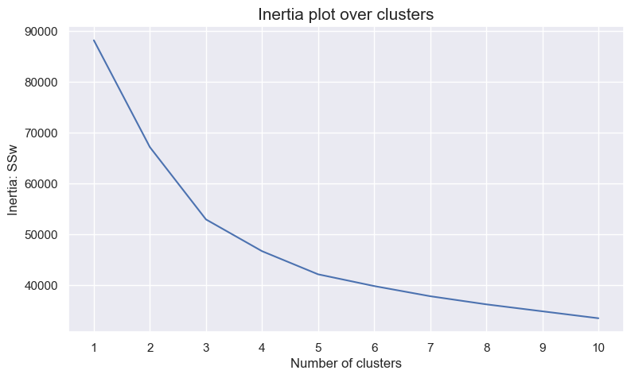

```python
# The inertia plot

fig, ax = plt.subplots(figsize=(9,5))

ax.plot(range_clusters, inertia)
ax.set_xticks(range_clusters)
ax.set_ylabel("Inertia: SSw")
ax.set_xlabel("Number of clusters")
ax.set_title("Inertia plot over clusters", size=15)

plt.show()
```

### **Silhouette Coefficient**

**Silhouette Coefficient formula for a single sample:** $$s = \frac{b - a}{max(a, b)}$$ , where:

- $a$: The mean distance between a sample and all other points in the same cluster.
- $b$: The mean distance between a sample and all other points in the next nearest cluster

If $b > a$, then what?

Then the sample is closer to the points in the cluster it is assigned to (compared to the points in the next nearest cluster)

$$s \text{ is positive }$$

[**If $b > a$, then what?**] -> **Good!** (Os pontos do mesmo cluster estão mais próximos do que os pontos do cluster mais próximo **OU** alto $b$ e baixo $a$ quando ele próprio é o centroid)

If $b = a$, then what?

*Then the sample is equally distant to the points in the cluster it is assigned to as well as the points in the next closest cluster*

$$s \text{ is 0}$$

[**If $b = a$, then what?**] -> **Ok!** (Os pontos do mesmo cluster estão igualmente distantes dos pontos do cluster mais próximo **OU** $(b-a)/b=0$ podia pertencer a qualquer cluster)

If $b < a$, then what?

*Then the sample is closer to the points in the next closest cluster (compared to the points in the same cluster).*

$$s \text{ is negative }$$

[**If $b < a$, then what?**] -> **Bad!** (Os pontos do mesmo cluster estão mais distantes do que os pontos do cluster mais próximo [OUTLIER ⚠️⚠️])

**If the average value of $s$ is high, then what?**

"Silhouette coefficients (as these values are referred to as) near +1 indicate that the sample is far away from the neighboring clusters. A value of 0 indicates that the sample is on or very close to the decision boundary between two neighboring clusters and negative values indicate that those samples might have been assigned to the wrong cluster."

- https://scikit-learn.org/stable/auto_examples/cluster/plot_kmeans_silhouette_analysis.html

**Silhouette Coefficient** ranges from -1 to 1. [COPILOT]

- **1**: The sample is far away from the neighboring clusters.
- **0**: The sample is on or very close to the decision boundary between two neighboring clusters.
- **-1**: The sample might have been assigned to the wrong cluster.
- **Negative values**: Incorrect clustering.
- **Values near 0**: Overlapping clusters.
- **Values near 1**: Well separated clusters.

```
For n_clusters = 2, the average silhouette_score is : 0.22169256242414487
For n_clusters = 3, the average silhouette_score is : 0.23695132157473936
For n_clusters = 4, the average silhouette_score is : 0.21049133734433312
For n_clusters = 5, the average silhouette_score is : 0.19486028421352744
For n_clusters = 6, the average silhouette_score is : 0.18736793579734382
For n_clusters = 7, the average silhouette_score is : 0.1698859786145844
For n_clusters = 8, the average silhouette_score is : 0.1668813803550606
For n_clusters = 9, the average silhouette_score is : 0.1574004473618112
For n_clusters = 10, the average silhouette_score is : 0.1510092734412441
```

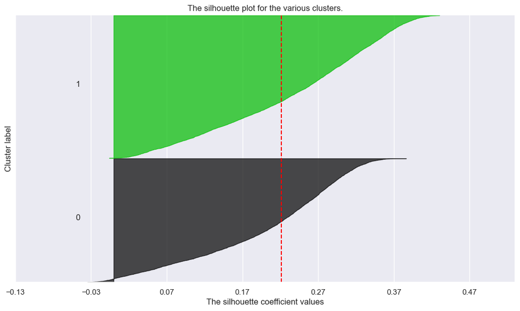

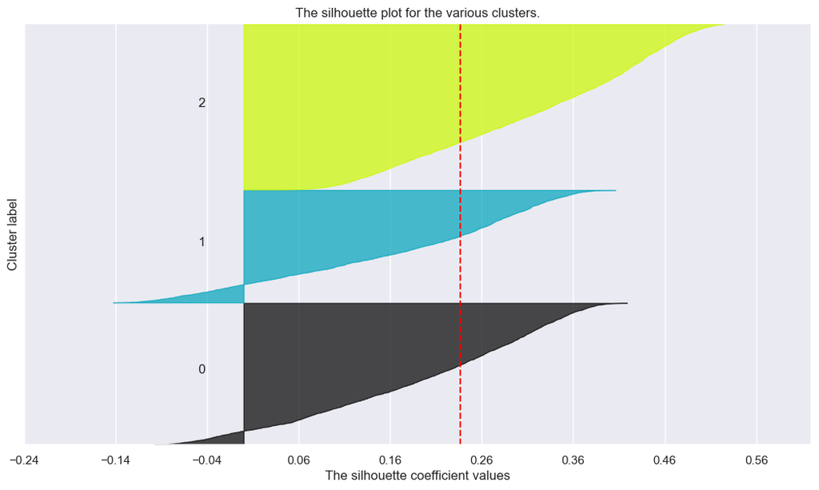

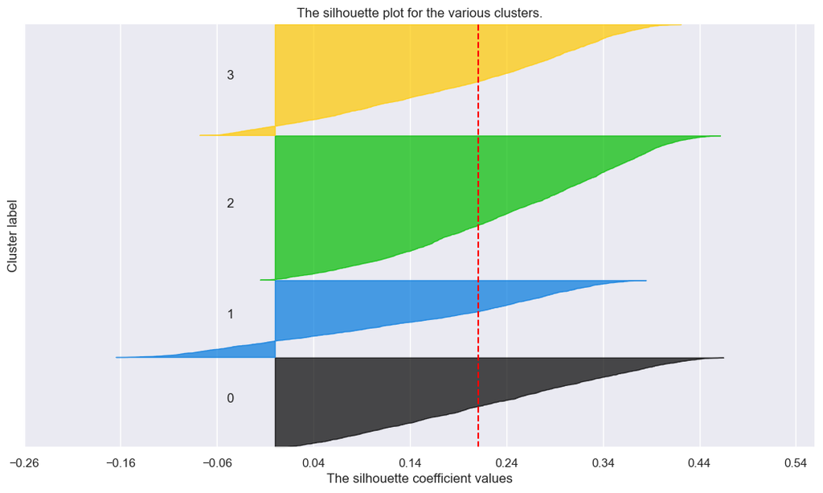

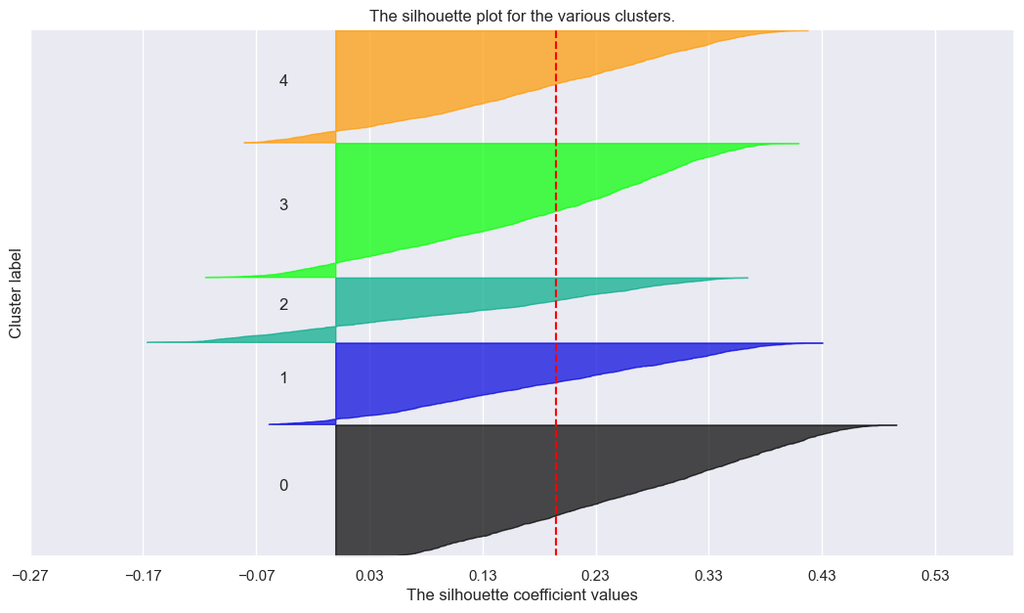

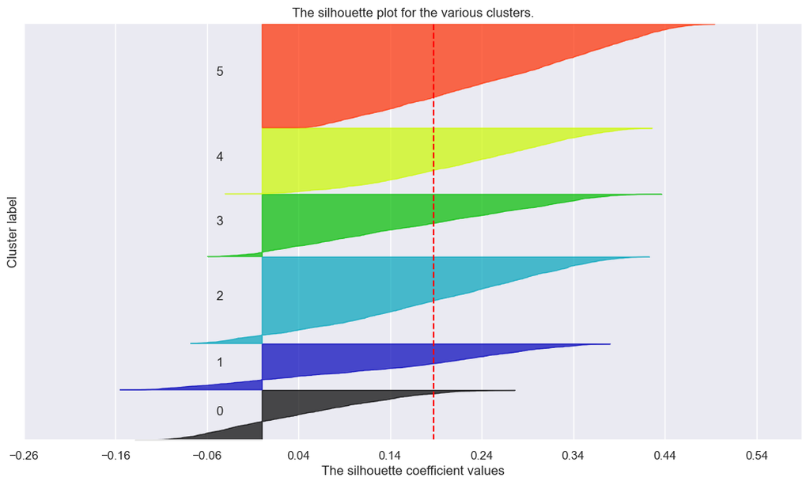

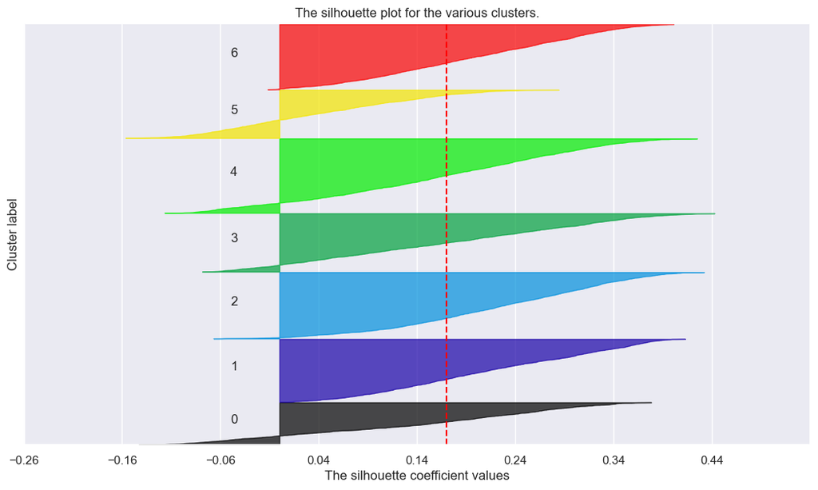

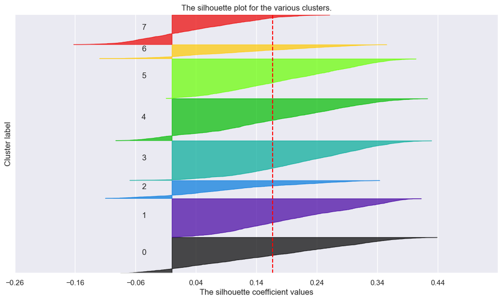

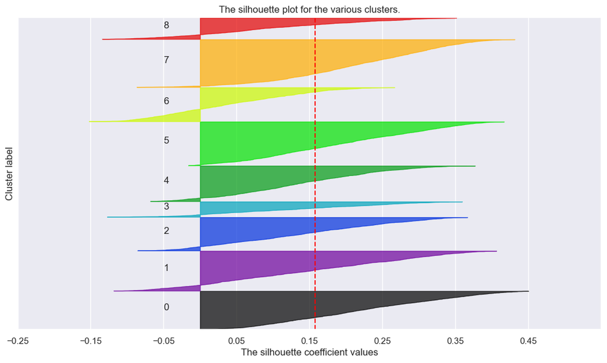

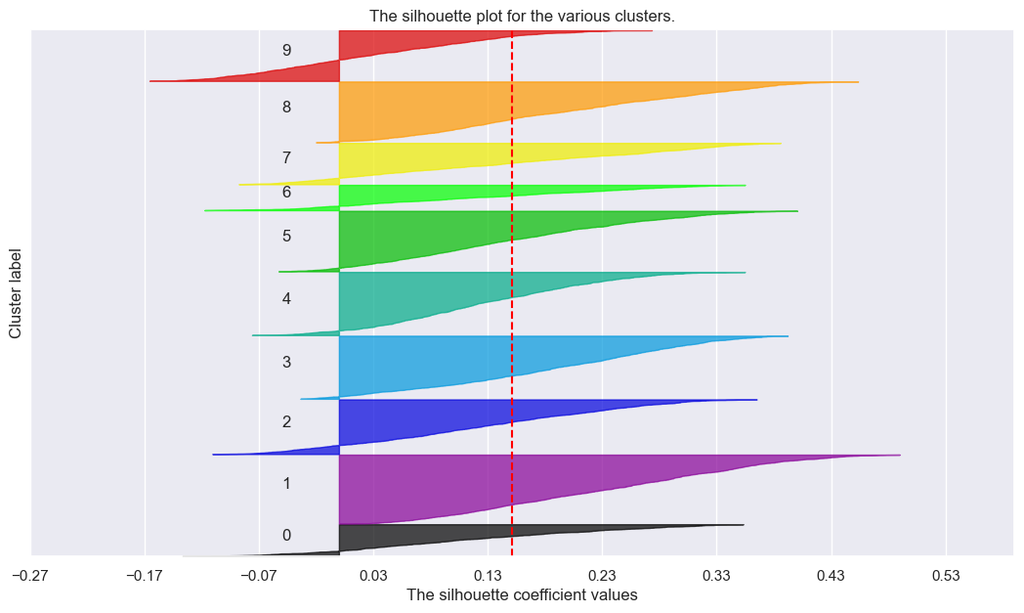

```python
# Adapted from:
# https://scikit-learn.org/stable/auto_examples/cluster/plot_kmeans_silhouette_analysis.html#sphx-glr-auto-examples-cluster-plot-kmeans-silhouette-analysis-py

# Storing average silhouette metric
avg_silhouette = []
for nclus in range_clusters:
    # Skip nclus == 1
    if nclus == 1:
        continue

    # Create a figure
    fig = plt.figure(figsize=(13, 7))

    # Initialize the KMeans object with n_clusters value and a random generator
    # seed of 10 for reproducibility.
    kmclust = KMeans(n_clusters=nclus, init='k-means++', n_init=15, random_state=1)
    cluster_labels = kmclust.fit_predict(df[metric_features])

    # The silhouette_score gives the average value for all the samples.
    # This gives a perspective into the density and separation of the formed clusters
    silhouette_avg = silhouette_score(df[metric_features], cluster_labels)
    avg_silhouette.append(silhouette_avg)
    print(f"For n_clusters = {nclus}, the average silhouette_score is : {silhouette_avg}")

    # Compute the silhouette scores for each sample
    sample_silhouette_values = silhouette_samples(df[metric_features], cluster_labels)

    y_lower = 10
    for i in range(nclus):
        # Aggregate the silhouette scores for samples belonging to cluster i, and sort them
        ith_cluster_silhouette_values = sample_silhouette_values[cluster_labels == i]
        ith_cluster_silhouette_values.sort()

        # Get y_upper to demarcate silhouette y range size
        size_cluster_i = ith_cluster_silhouette_values.shape[0]
        y_upper = y_lower + size_cluster_i

        # Filling the silhouette
        color = cm.nipy_spectral(float(i) / nclus)
        plt.fill_betweenx(np.arange(y_lower, y_upper),
                          0, ith_cluster_silhouette_values,
                          facecolor=color, edgecolor=color, alpha=0.7)

        # Label the silhouette plots with their cluster numbers at the middle
        plt.text(-0.05, y_lower + 0.5 * size_cluster_i, str(i))

        # Compute the new y_lower for next plot
        y_lower = y_upper + 10  # 10 for the 0 samples

    plt.title("The silhouette plot for the various clusters.")
    plt.xlabel("The silhouette coefficient values")
    plt.ylabel("Cluster label")

    # The vertical line for average silhouette score of all the values
    plt.axvline(x=silhouette_avg, color="red", linestyle="--")

    # The silhouette coefficient can range from -1, 1
    xmin, xmax = np.round(sample_silhouette_values.min() -0.1, 2), np.round(sample_silhouette_values.max() + 0.1, 2)
    plt.xlim([xmin, xmax])

    # The (nclus+1)*10 is for inserting blank space between silhouette
    # plots of individual clusters, to demarcate them clearly.
    plt.ylim([0, len(df[metric_features]) + (nclus + 1) * 10])

    plt.yticks([])  # Clear the yaxis labels / ticks
    plt.xticks(np.arange(xmin, xmax, 0.1))
```

- Cada **linha** no gráfico representa **um ponto de dados** -> Ordenado conforme o score ao cluster que pertence.
- A linha pontilhada é a média dos valores de silhueta para todos os pontos.

> Isto é o resultado de cada ponto e depois temos as silhouette negativas. Boa sol. se tivermos muito no positivo

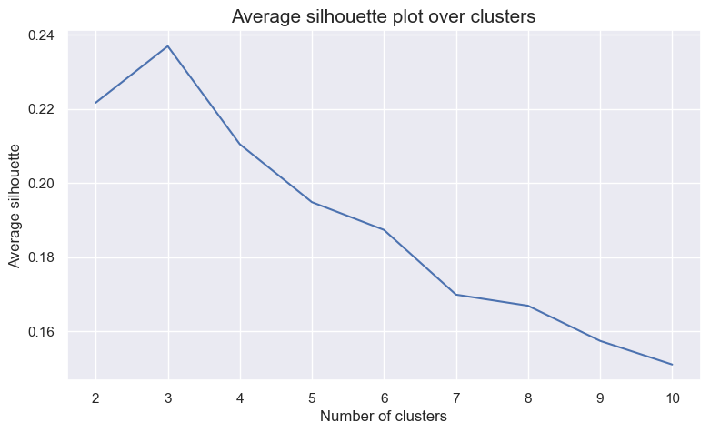

```python
# The average silhouette plot
# The inertia plot
plt.figure(figsize=(9,5))


#  Why range_clusters[1:] ?
# Remember we skipped k=1 in the cell above

plt.plot(range_clusters[1:], ## Plot X-axis;
         avg_silhouette)     ## Plot Y-axis

plt.ylabel("Average silhouette")
plt.xlabel("Number of clusters")
plt.title("Average silhouette plot over clusters", size=15)
plt.show()
```

> Aqui **mais clusters não dá melhores resultados como em `Inertia`**

### **Final KMeans clustering Solution**

```python
# final cluster solution
number_clusters = 3
kmclust = KMeans(n_clusters=number_clusters, init='k-means++', n_init=15, random_state=1)
km_labels = kmclust.fit_predict(df[metric_features])
km_labels
```

```
array([0, 0, 1, ..., 2, 0, 0])
```

```python
# Characterizing the final clusters
df_concat = pd.concat((df[metric_features], pd.Series(km_labels, name='labels', index=df.index)), axis=1)
df_concat.groupby('labels').mean()
```

| labels | income | frq | rcn | clothes | kitchen | small_appliances | toys | house_keeping | per_net_purchase | spent_online |
| --- | --- | --- | --- | --- | --- | --- | --- | --- | --- | --- |
| 0 | 1.053253 | 1.061420 | -0.070921 | -0.228899 | 0.037830 | 0.373165 | 0.040932 | 0.002806 | -1.030062 | 0.687154 |
| 1 | -1.042072 | -0.846226 | 0.101268 | -1.030222 | 0.805183 | 0.474856 | 0.810857 | 0.826834 | 0.695189 | -0.768122 |
| 2 | -0.191784 | -0.332037 | -0.008249 | 0.896822 | -0.580262 | -0.642307 | -0.586776 | -0.565037 | 0.407992 | -0.065062 |

### **How can we combine the 2 algorithms? (`KMeans` and `Hierarchical`)**

- **AgglomerativeClustering** is a hierarchical clustering algorithm that builds a tree of clusters.
- **KMeans** is a partitioning algorithm that clusters data points into K clusters.

**How can we combine the two?**

1. Use **HC** dendogram to find $k$ (number of clusters). Then use KM with this $k$. **[Mas o prof. não gosta muito]**
2. Use **KM** with a large $k$. Use **HC** to find $k$ menor!

> We can use the **Hierarchical Clustering** to determine the number of clusters and then use **KMeans** to cluster the data points into those clusters.

## **Exercises**

#### **Exercise:** Visualize the cluster means as a heatmap

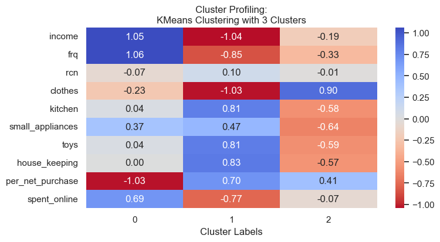

```python
fig, ax = plt.subplots(figsize=(8,4))

km_profile = df_concat.groupby('labels').mean().T

sns.heatmap(km_profile,
            # Remember how to improve this figure?

            ax=ax, cmap='coolwarm_r', center=0, annot=True, fmt=".2f")

ax.set_xlabel("Cluster Labels")
ax.set_title("Cluster Profiling:\nKMeans Clustering with 3 Clusters")
plt.show()
```

#### **Exercise:** Apply Hierarchical Clustering and K-means on the Principal Components

Choose the appropriate parameters and number of clusters for each algorithm and interpret each cluster based on the Principal Components interpretation:

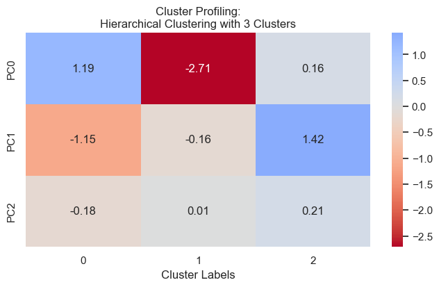

```python
#### **Exercise:** Apply Hierarchical Clustering and K-means on the Principal Components
# Choose the appropriate parameters and number of clusters for each algorithm and interpret each cluster based on the Principal Components interpretation:

# Hierarchical Clustering
number_clusters = 3
aggclust = AgglomerativeClustering(n_clusters=number_clusters, linkage='ward')
agg_labels = aggclust.fit_predict(df[pc_features])

df_concat = pd.concat((df[pc_features], pd.Series(agg_labels, name='labels', index=df.index)), axis=1)
df_concat.groupby('labels').mean()

fig, ax = plt.subplots(figsize=(8,4))

agg_profile = df_concat.groupby('labels').mean().T

sns.heatmap(agg_profile,
            ax=ax, cmap='coolwarm_r', center=0, annot=True, fmt=".2f")

ax.set_xlabel("Cluster Labels")
ax.set_title("Cluster Profiling:\nHierarchical Clustering with 3 Clusters")
plt.show()
```

#### **Exercise:** Compare the cluster memberships between KMeans with `metric_features` vs `pc_features`

```python
# Final cluster solution using metric features:
number_clusters = 3
kmclust = KMeans(n_clusters=number_clusters, init='k-means++', n_init=15, random_state=1)
km_labels = kmclust.fit_predict(df[metric_features])
km_labels
```

```
array([0, 0, 1, ..., 2, 0, 0])
```

```python
# Final cluster solution using PC features:
number_clusters = 3
kmclust = KMeans(n_clusters=number_clusters, init='k-means++', n_init=15, random_state=1)
km_labels = kmclust.fit_predict(df[metric_features])
km_labels

pc_kmclust = KMeans(n_clusters=3, init='k-means++', n_init=15, random_state=1)
pc_km_labels = pc_kmclust.fit_predict(df[pc_features])
pc_km_labels
```

```
array([2, 2, 1, ..., 0, 2, 2])
```

```python
# Create crosstab between km_labels and pc_km_labels
pd.crosstab(
    pd.Series(km_labels, name='km_labels', index=df.index),
    pd.Series(pc_km_labels, name='pc_km_labels', index=df.index))
```

| pc_km_labels km_labels | 0 | 1 | 2 |
| --- | --- | --- | --- |
| 0 | 10 | 26 | 2938 |
| 1 | 26 | 2339 | 1 |
| 2 | 3458 | 19 | 0 |

> Como não existe grande $\neq$ de clusters, é bom pq os PCs **retêm** a maior parte da variância dos dados.

> Podemos ver que a maioria dos pontos do **1º cluster** ficam juntos apenas têm um *label* diferente Fez ***Cluster Profilling*** com **heatmap** para cluster feitos com PCA e feitos com normal feature

#### ***Any insights?***

- What are the differences between the clusters?
- How do the clusters differ in terms of the Principal Components? **[NO]**
- What are the characteristics of the clusters?
- How do the clusters differ in terms of the original features?
- What are the characteristics of the clusters?

#### **Exercise:** Compare the cluster memberships between KMeans and the Hierarchical Clustering solution

##### **Remember:** Final Hierarchical clustering solution

```python
# final cluster solution
linkage = "ward"
distance = "euclidean"
n_clusters = 4

hclust = AgglomerativeClustering(linkage=linkage, metric=distance, n_clusters=n_clusters)

hc_labels = hclust.fit_predict(df[metric_features])
```

```python
# Create crosstab here
pd.crosstab(pd.Series(km_labels, name='km_labels', index=df.index),
            pd.Series(hc_labels, name='hc_labels', index=df.index))
```

| hc_labels km_labels | 0 | 1 | 2 | 3 |
| --- | --- | --- | --- | --- |
| 0 | 1223 | 43 | 1705 | 3 |
| 1 | 67 | 1289 | 133 | 877 |
| 2 | 2286 | 1178 | 10 | 3 |

#### **Exercise:** Compare the cluster memberships between KMeans and the Hierarchical Clustering solution

***But use the same number of clusters***

```python
# final cluster solution
kmclust = KMeans(n_clusters=4, init='k-means++', n_init=15, random_state=1)
km4_labels = kmclust.fit_predict(df[metric_features])
km4_labels
```

```
array([3, 3, 1, ..., 2, 3, 0])
```

```python
# Create crosstab here
pd.crosstab(pd.Series(km4_labels, name='km4_labels', index=df.index),
            pd.Series(hc_labels, name='hc_labels', index=df.index))
```

| hc_labels km4_labels | 0 | 1 | 2 | 3 |
| --- | --- | --- | --- | --- |
| 0 | 1824 | 4 | 47 | 0 |
| 1 | 33 | 598 | 121 | 856 |
| 2 | 1104 | 1876 | 13 | 23 |
| 3 | 615 | 32 | 1667 | 4 |

## **Next Session: `Self-Organizing Maps`**